# Модели временных рядов с гетероскедастичностью

## ARCH модель

Пусть нам дан временной ряд, удовлетворяющий модели авторегрессии порядка $p$
$$x_{t}=c+\phi_1x_{t-1}+...+\phi_{p}x_{t-p}+u_{t}$$
где $u_{t}$-белый шум
$$Eu_{t} = 0$$
$$Eu_{t}u_{s} = σ^2$$
при $s=t$ иначе 0

Оптимальным линейным прогнозом такого ряда является условное математическое ожидание $x_{t}$ при условии, что нам известна история процесса до момента $t-1$ включительно
$$E[x_{t}|x_{t-1},x_{t-2,....}]=c+\phi_1x_{t-1}+...+\phi_{p}x_{t-p}$$
(1)

Если предположить стационарность процесса $x_{t}$ то безусловное математическое ожидание процесса не зависит от времени и равно
$$E[x_{t}] = c+\phi_1E[x_{t-1}]+...+\phi_{p}E[x_{t-p}]=
c+\phi_1E[x_{t}]+...+\phi_{p}E[x_{t}]$$
Отсюда

$$E[x_{t}]=(с/(1-\phi_1-...-\phi_{p}))$$

Однако из выражения (1) видно, что условное математическое ожидание от времени зависит.

На практике довольно часто встречается необходимость прогнозирования не только средних значений, но и дисперсии. Предположим, что и сам процесс шума $u_{t}$(точнее его квадрат) в свою очередь следует процессу авторегрессии поряда $m$

$$u_{t}^2=\eta+\alpha_1u_{t-1}^2+...+\alpha_m u_{t-m}^2+v_{t}$$
(2) Где $v_{t}$- процесс белого (но уже другого) шума
$$Ev_{t} = 0$$
$$Ev_{t}v_{s} = \lambda^2$$
при $s=t$ иначе 0

При прогнозировании ряда $x_{t}$ мы показали, что $u_{t}$- ошибка прогнозирования. Из представления (2) следует, что оптимальным линейным прогнозом $u_{t}^2$ будет в свою очередь следующее условное математическое ожидание.
$$E[u^2_{t}|u_{t-1}^2,u^2_{t-2},....]=\eta+\alpha_1u^2_{t-1}+...+\alpha_{m}u^2_{t-m}$$
(3) Определение. Процесс белого шума, удовлетворяющий (2) называют авторегрессионным гетероскедастическим процессом порядка m. Обозначают это следующим образом $u_{t}\sim ARCH(m)$. Такой класс процессов впервые был предложен Engle в 1982 году. В 2003 году вклад Engle был отмечен Нобелевской премией по экономике. Так как процесс $u_{t}$ - случайный, a квадрат его $u_{t}^2$ естественно должен быть всегда неотрицательным, то от представления (2) естественно потребовать, что при любых реализациях $u_{t}$ - его квадрат был всегда нетрицательным. Этого можно добится следеющими предположениями 1. Процесс $v_{t}$ ограничен снизу $-\eta$, где $\eta>0$ 2. Все $\alpha_{i}>0;i=1,...,m$ Естественно также предполагать стационарность процесса $u_{t}^2$. Это достигается предположением, что корни соответсвующего характеристического уравнения многочлена
$$1-\alpha_1z-...-\alpha_{m}z^{m}=0$$
должны лежать вне единичного круга $|z|≤1$

Это предположение, а вместе с предположением 2. эквивалентны тому, что
$$\alpha_1+...+\alpha_{m}<1$$

При выполнении всех выше сделанных предположений безусловную дисперсию процесса $u_{t}$ можно вычислить по следующей формуле
$$Eu_{t}^2=(\eta/(1-(\alpha_1+...+\alpha_{m})))$$
Существует альтернативное и более удобное представление ARCH(m). Предположим, что

$$u_{t}=e_{t}\sqrt(h_{t})$$
, (4)

где $e_{t}$ -последовательность независимых одинаково распределенных случайных величин с нулевым математическим ожиданием и единичной дисперсией

$$E[e_{t}] = 0$$
,
$$D[e_{t}] = 1$$
,

а $h(t)$ удовлетворяют соотношению
$$h_{t}=\eta+\alpha_1u^2_{t-1}+...+\alpha_{m}u^2_{t-m}$$
(5) Из соотношения (4) следует, что
$$E[u_{t}^2|u_{t-1},u_{t-2},...]=\eta+\alpha_1u^2_{t-1}+...+\alpha_{m}u^2_{t-m}$$

следовательно $u_{t}\sim ARCH(m)$

### Оценивание параметров ARCH модели.

Предположим, что у нас есть линейная регрессионная модель с шумом, который в свою очередь предствляется в виде ARCH процеса.
$$y_{t}=x_{t}′\beta+u_{t}$$

где $x_{t }$-вектор из независимых (предикторов) переменных, среди которых могут быть и так называемые лаговые переменные от $y_{t}$, например $y_{t-1},y_{t-2}$ и т.д. А $u_{t}$ удовлетворяет соотношениям (4) и (5). Удобно занумеровать значения имеющихся ряда наблюдений $y_{t}$ индексами, начиная с $t=-m+1,-m+2,...,0,1, ...,T$. Первые $m$ значенией мы будем использовать для построения условного распредения, а значения с индексами от 1 до $Т$ непосредстевнно для оценивания. Таким образом для произвольного момента времени $t$ обозначим через $Y_{t}$ следующий вектор
$$Y_{t}=(y_{t},y_{t-1},...,y_0,...,y_{-m+1},x_{t}′,x_{t-1},...,x′_0,...,x_{-m+1}′$$

Пусть $e_{t}$- последовательность независимых стандартно нормально распределенных случайных величин независимых одновременно от $x_{t}$ и от $Y_{t-1}$. Тогда, при сделанных выше предположениях условное распределение $y_{t}$ при условии, что $x_{t}$ и $Y_{t-1}$ известно будет нормальным с математическим ожиданием $x_{t}′\beta$ и дисперсией $h_{t}$
$$f(y_{t}|x_{t},Y_{t-1})=(1/(\sqrt{(2\pi h_{t}})))exp(-(((y_{t}-x_{t}′\beta)^2)/(2h_{t})))$$
где
$$h_{t}=\mu+\alpha_1(y_{t-1}-x_{t-1}′\beta)^2+...+\alpha_{m}(y_{t-m}-x_{t-m}′\beta)^2=$$
(8) Запишем (8) в виде cкалярного произведения двух векторов
$$=[z_{t}(\beta)]′\delta$$
где
$$\delta=(\mu,\alpha_1,...,\alpha_{m})′$$
,

а
$$[z_{t}(\beta)]′=[1,(y_{t-1}-x_{t-1}′\beta)^2,...,(y_{t-m}-x_{t-m}′\beta)^2]$$

Обозначим через $\theta$ вектор параметров подлежащих оценке. Это будет вектор вида

$$\theta=[\beta′,\delta′]$$

Тогда логарифм условной относительно первых m наблюдений функции правдоподобия запишется следующим образом
$$L(\theta) = \sum_{t=1}^{T}ln(f(y_{t}|x_{t},Y_{t-1};\theta))=
-(T/2)ln(2\pi)-(1/2)\sum_{t=1}^{T}ln h_{t}-(1/2)\sum_{t=1}^{T}(((t_{t}-x_{t}′\beta)^2)/(h_{t}))$$
Для получения оценок максимального правдоподобия чаше всего используют какой-нибудь градиентный метод. Познакомимся с ARCH(m) процессом в следующим фрейме. Здесь моделируется ARCH(2) с добавленным ARMA(1,1) процессом.

https://shiny.ilykei.com/ANDoynikov/ARCH_GARCH_Model/ARCH%282%29_Model/"

Моделируемая модель выглядит так:
$$y_t=\mu + \phi_1y_{t-1}+\theta_1a_{t-1}+a_t$$
, где $a_t=\sqrt{h_t}\epsilon_t$$
$$h_t= \omega+\alpha_1h_{t-1}+\alpha_2h_{t-2}$$

R код моделирования выглядит так. Для работы ARCH процессами нам понадобится библиотеки rugarch и fBasics

```r
  library(rugarch)
  library(fBasics)
```

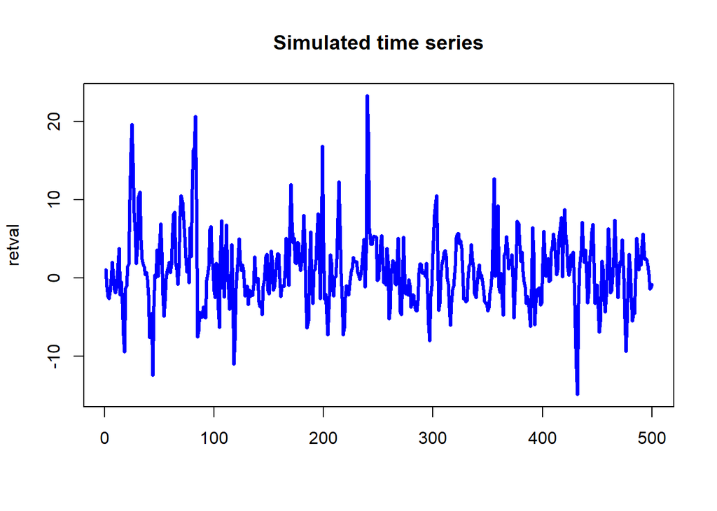

```r
  r = rnorm(1000)
  spec <- ugarchspec(variance.model = list(model ="sGARCH",garchOrder = c(2,0)), mean.model = list(armaOrder = c(1, 1)),distribution.model = "norm")
  fit <- ugarchfit(r, spec = spec)
  mu <- 0.5
  AR <- 0.4
  MA <- 0.7
  omega <- 3
  alpha1 <- 0.45
  alpha2 <- 0.3
  fit@fit$ipars[1]<-mu #mu
  fit@fit$ipars[2]<-AR #ar1
  fit@fit$ipars[3]<-MA #ma1
  fit@fit$ipars[4]<-0.0 #arfima
  fit@fit$ipars[5]<-0.0  #arch
  fit@fit$ipars[7]<-omega  #omega
  fit@fit$ipars[8]<-alpha1   #alpha1
  fit@fit$ipars[9]<-alpha2 #beta1

  #fit@fit$coef <- fit@fit$ipars
  #        fit@fit$matcoef <-fit@fit$ipars
  sim <- ugarchsim(fit,n.sim=500, n.start=1, m.sim=1, startMethod="sample")
  retval <- sim@simulation$seriesSim
  matplot(retval,type = "l",lwd = 3,col = "blue",main = "Simulated time series")
```

Вот так выглядит гистограмма смоделированного ряда по сравнению с плотностью нормального распределения

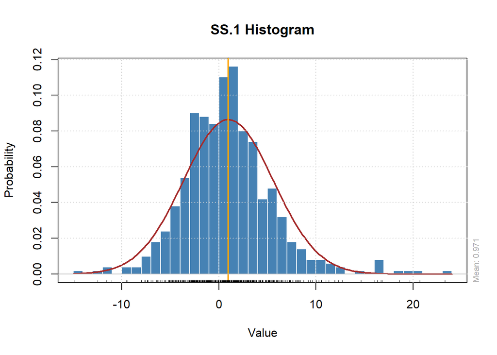

```r
  histPlot(as.timeSeries(sim@simulation$seriesSim))
```

Cмоделированный процесс для дисперсии $\sigma_t^2$ можно посмотреть вот так:

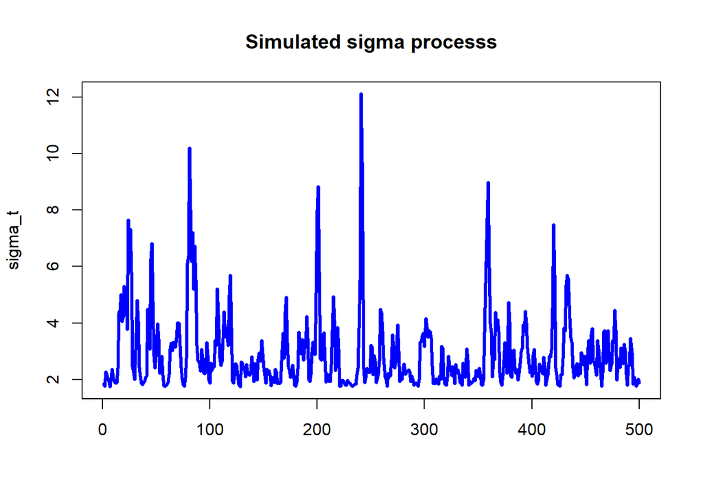

```r
  sigma_t <- sim@simulation$sigmaSim
  matplot(sigma_t,type = "l",lwd = 3,col = "blue",main = "Simulated sigma processs")
```

Результаты оценивания методом максимального правдоподобия

```r
  fitarch <- ugarchfit(retval, spec = spec)
  fitarch@fit$coef
```

```
##        mu       ar1       ma1     omega    alpha1    alpha2
## 0.6548385 0.4561656 0.6655136 2.2425539 0.5832564 0.3250028
```

Остатки после удаления модели $\epsilon_t$.

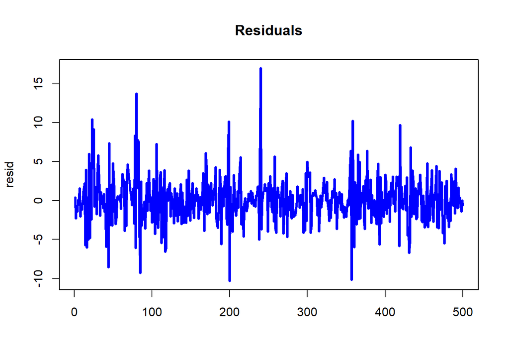

```r
  resid <- fitarch@fit$residuals
  matplot(resid,type = "l",lwd = 3,col = "blue",main = "Residuals")
```

QQ-график остатков

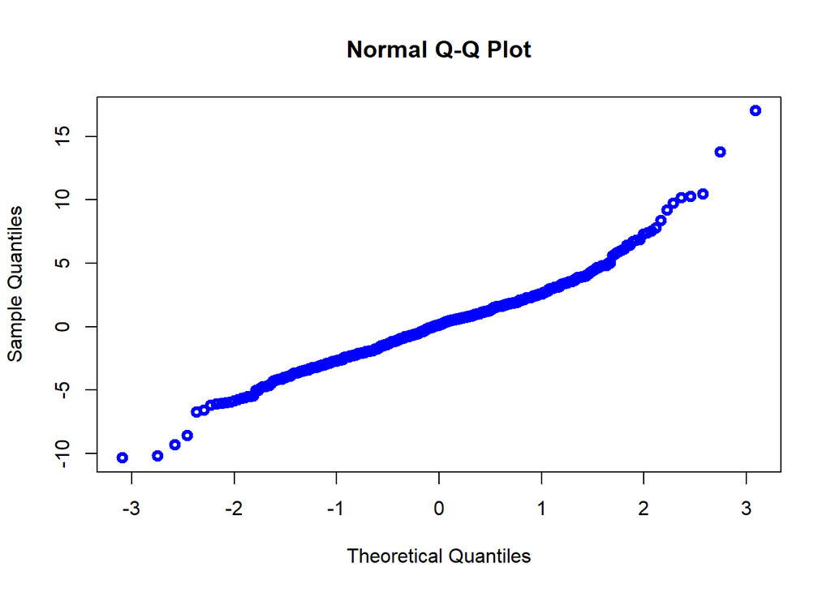

```r
qqnorm(resid ,lwd=3,col = "blue")
```

## GARCH модель

В предыдущем разделе $h(t)$ удовлетворяло соотношению
$$h_{t}=\mu+\alpha_1u^2_{t-1}+...+\alpha_{m}u^2_{t-m}$$

Более общим будет процесс в котором условная дисперсия зависит не от конечного, а бесконечного числа задержек $u^2_{t-j}, j=1,2,...$ В операторном виде это можно записать так.
$$h_{t} = \mu+\pi(B)u_{t}^2 (1)$$
$$\pi(B) = \sum_{j=1}^{\infty}\pi_{j}B^{j}$$

Эта идея реализуется, когда $\pi(B)$ представим в виде отношения двух конечных полиномов
$$\pi(B)=((\alpha(B))/(1-\delta(B)))=((\alpha_1B+...+\alpha_{m}B^{m})/(1-\delta_1B-...-\delta_{r}B^{r}))$$
здесь мы предположим, что корни $1-\delta(B)$ лежат вне единичного круга $|B|≤1$

Умножив обе части (1) на $1-\delta(B)$ получим
$$[1-\delta(B)]h_{t}=[1-\delta(B)]\mu+\alpha(B)u_{t}^2$$
или
$$h_{t} = κ+\delta_1h_{t-1}+...+\delta_{r}h_{t-r}+\alpha_1u_{t-1}^2+...+\alpha_{m}u_{t-m}^2 (2)$$
где $κ = [1-\delta_1-...-\delta_{r}]\mu$ Соотношения (2) и называют процессом обобщенной условной авторегрессии с гетероскедастичностью. (GARCH(r,m) - модель). Модель впервые была предложена Bollerslev в 1986 году.

Неотрицательность для $u_{t}^2$ обеспечивается предположением, что $κ≥0,\alpha_{i}≥0,\delta_{i}≥0; i=1,...,p=max(r,m)$. Здесь мы доопределили нулями недостающие либо $\alpha_{i}$ либо $\delta_{i}$. Cтационарность гарантируется тем, корни характеристического моногочлена вида
$$1+(\alpha_1+\delta_1)z+...+(\alpha_{p}+\delta_{p})z^{p}=0$$
лежат вне единичного круга $|z|≤1$

Совместно с предположением о нетрицательности $\alpha_{i}$ и $\delta_{i}$ предположение о стационарности эквивалентно тому, что
$$(\alpha_1+\delta_1)+...+(\alpha_{p}+\delta_{p})<1$$

При сделанных предположениях безусловное математическое ожидание для $u_{t}^2$ будет равно
$$Eu_{t}^2=(κ/(1-((\alpha_1+\delta_1)+...+(\alpha_{p}+\delta_{p}))))$$

Ниже приведен пример кода на R для моделирования GARCH(2,2) модели с добавленной ARMA(1,1). Обратите внимание мы поменяем распределение шума $\epsilon_t$ на стандартное распределение Стьюдента с нулевым математическим ожиданием и дисперсией 1.

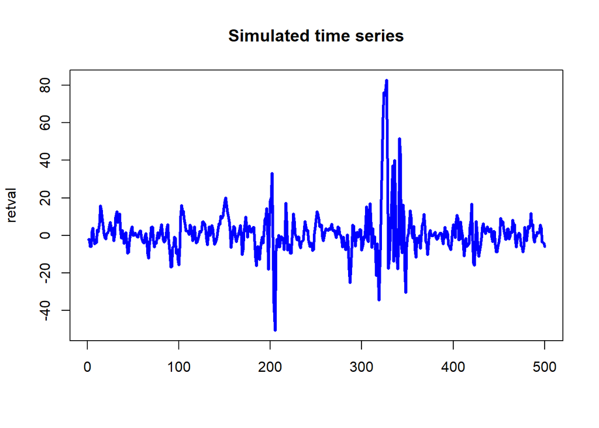

```r
  r = rnorm(1000)
  spec <- ugarchspec(variance.model = list(model ="sGARCH",garchOrder = c(2,2)), mean.model = list(armaOrder = c(1, 1)),distribution.model = "std")
  fit <- ugarchfit(r, spec = spec)
  mu <- 0.5
  AR <- 0.4
  MA <- 0.7
  omega <- 3
  alpha1 <- 0.25
  alpha2 <- 0.3
  betta1 <- 0.2
  betta2 <- 0.2

  fit@fit$ipars[1]<-mu #mu
  fit@fit$ipars[2]<-AR #ar1
  fit@fit$ipars[3]<-MA #ma1
  fit@fit$ipars[4]<-0.0 #arfima
  fit@fit$ipars[5]<-0.0  #arch
  fit@fit$ipars[7]<-omega  #omega
  fit@fit$ipars[8]<-alpha1   #alpha1
  fit@fit$ipars[9]<-alpha2 #beta1
  fit@fit$ipars[10]<-betta1   #betta1
  fit@fit$ipars[11]<-betta2 #betta2

  sim <- ugarchsim(fit,n.sim=500, n.start=1, m.sim=1, startMethod="sample")
  retval <- sim@simulation$seriesSim
  matplot(retval,type = "l",lwd = 3,col = "blue",main = "Simulated time series")
```

Обратите вниманиe как изменилась гистограмма смоделированного ряда по сравнению с плотностью нормального распределения

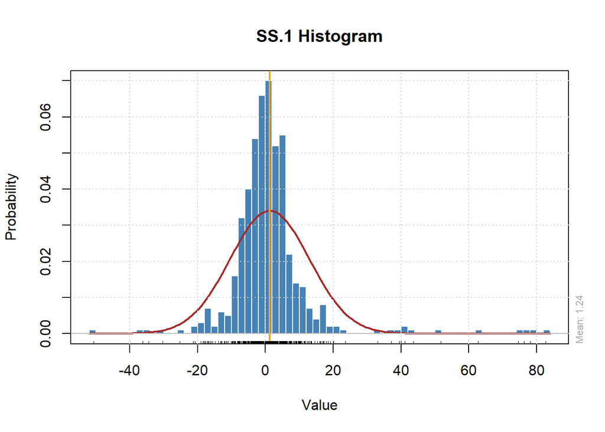

```r
  histPlot(as.timeSeries(sim@simulation$seriesSim))
```

Оценку неизвестных параметров GARCH модели проводится аналогично как и для ARCH методом максимального правдоподобия. Соответсвующее выражение для логарифма функции правдоподобия можно взять из работы Bollerslev 1986 года.

```r
  fitarch <- ugarchfit(retval, spec = spec)
  fitarch@fit$coef
```

```
##         mu        ar1        ma1      omega     alpha1     alpha2      beta1
##  0.3427458  0.3856956  0.6475046  3.1300049  0.4112596  0.1599357  0.2030285
##      beta2      shape
##  0.1597788 34.3089584
```

Подробнее ознакомитсяя с GARCH(m,k) процессом можно в следующим фрейме. Здесь моделируется GARCH(1,1) с добавленным ARMA(1,1) процессом и нормальным распределением шума $\epsilon_t$.

https://shiny.ilykei.com/ANDoynikov/ARCH_GARCH_Model/GARCH_Model/

## Прогнозирование GARCH моделей

Прогнозирование рассмотрим на примере модели AR(1)$GARCH(1,1).

$$x_t=\phi_1x_{t-1}+\theta_1\sigma_{t-1}\epsilon_{t-1}+\sigma_t\epsilon_t$$
$$\sigma_t^2= \omega+\alpha a_t^2+ \beta \sigma^2_{t-1}$$
$$a_t=\sigma_t\epsilon_t; \epsilon_t\sim N(0,1)$$

Обозначим для момента времени $t$ прогноз на $l$ моментов времени вперед $\widetilde{x}_t(l)$. Как и в ARMA моделях условное математическое ожидание будет минимальным в среднеквадратичном прогнозом
$$\widetilde x_t(l) = E(x_{t+l}|x_1,x_2,...,x_t)=\phi_1\widetilde x_{t}(l-1)$$
, где $\widetilde x_t(k) = E(x_{t+k}|x_1,x_2,...,x_t)$ if $k>0$

и

$\widetilde x_t(k) = x_{t+k}$ для $k\le 0$.

Пусть $\widetilde \sigma_t^2(l)$ прогноз квадрата волатильности в момент времени $t$ на $l$ моментов вперед.
$$\widetilde \sigma_t^2(l) = E(\sigma^2_{t+l}|\sigma^2_1,\sigma^2,...,\sigma^2_t)=\alpha\widetilde a^2_{t}(l-1)+\beta\widetilde \sigma^2_{t}(l-1)$$
, где

$\widetilde a^2_t(k) = 0$ if $k>0$;

иначе

$\widetilde a^2_t(k) = x_{t+k}-\widetilde x_{t}(k)$ if $k \le 0$.

Обратим внимание, что прогноз самого ряда $x_t$ точно такой же, как если бы у нас просто была модель AR(1). GARCH отражается только на доверительных интервалах прогноза Следующий фрейм дает представление о возможностях прогнозирования по GARCH моделям

https://shiny.ilykei.com/ANDoynikov/ARCH_GARCH_Model/GARCH_Forecast/

Во многом по этим причинам позднее появились обобщения модели для учета GARCH характера модели в прогнозах самого значения процесса $x_t$, а не только в доверительных интервалов. Исторически первой появилась модель

## GARCH-M модель

В финансовых рядах доходность актива может зависить от волатильности. Рассмотрим модель GARCH-M символ “М” в названии модели означает “in the maean”. Простейшая GARCH-M(1,1) модель записывается следующим образом

$$r_t=\mu+c\sigma_t^2+a_t,a = \sigma_t\epsilon_t$$
$$\sigma_t^2= \alpha_0+\alpha_1a^2_{t-1}+\beta_1\sigma_{t-1}^2$$

Знак параметра $c$ определяет тип зависимости динамики рейта от волатильности (положительную и отрицательную корреляцию между этими параметрами). Озакомиться с процессом ,увидеть влияние параметров на процесс можно в следующем фрейме. https://shiny.ilykei.com/ANDoynikov/ARCH_GARCH_Model/ARCH_M/

```r
library(fGarch)
source('./garchM.R')
data <- read.csv('./RubleRates.csv',sep=',')
head(data)
```

```
##          X318x6      Rub.Usd        brent        sp500      GAZPROM
## 1 1/11/16 12:00 -0.005162439  0.009705793  0.006734183  0.001774754
## 2 1/11/16 13:00 -0.002184241  0.005407029 -0.003577910 -0.002952683
## 3 1/11/16 14:00  0.001061344 -0.008066926 -0.002706078 -0.004145998
## 4 1/11/16 15:00 -0.001162265  0.001807229  0.002400334 -0.002155974
## 5 1/11/16 16:00 -0.001411732 -0.000300661 -0.001561687  0.001043064
## 6 1/11/16 17:00  0.003057320  0.001203008  0.003076121  0.000893123
##           Gold       EUR.USD
## 1 -0.005335021 -0.0015779090
## 2 -0.000727273  0.0001286370
## 3  0.004002911  0.0014607660
## 4 -0.000906125 -0.0001743020
## 5  0.000544168 -0.0000367016
## 6 -0.002356780 -0.0015874040
```

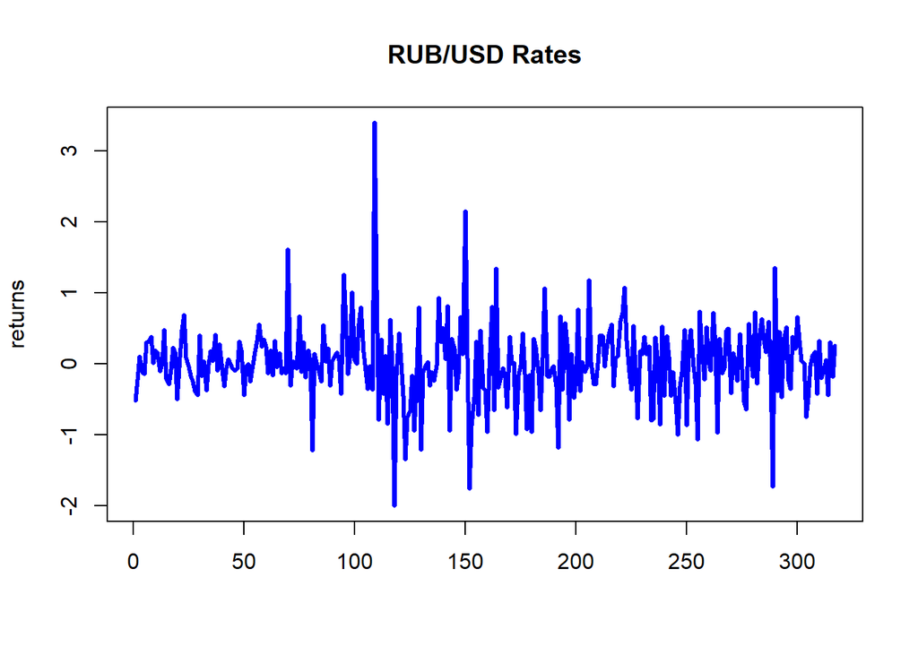

```r
rubusd <- data$Rub.Usd
returns <- rubusd * 100
matplot(returns,type="l",lwd=3,col = "blue",main = "RUB/USD Rates")
```

```r
g <- garchM(returns)
```

```
## Maximized log-likehood:  -248.9429
##
## Coefficient(s):
##          Estimate  Std. Error  t value Pr(>|t|)
## mu     0.11735896  0.09305450  1.26119 0.207242
## gamma -0.37890877  0.32345816 -1.17143 0.241426
## omega  0.00856316  0.00424741  2.01609 0.043790 *
## alpha  0.03897431  0.01574786  2.47489 0.013328 *
## beta   0.93515465  0.02128800 43.92872  < 2e-16 ***
## ---
## Signif. codes:  0 '***' 0.001 '**' 0.01 '*' 0.05 '.' 0.1 ' ' 1
```

Оценка квадрата волатильности рубля

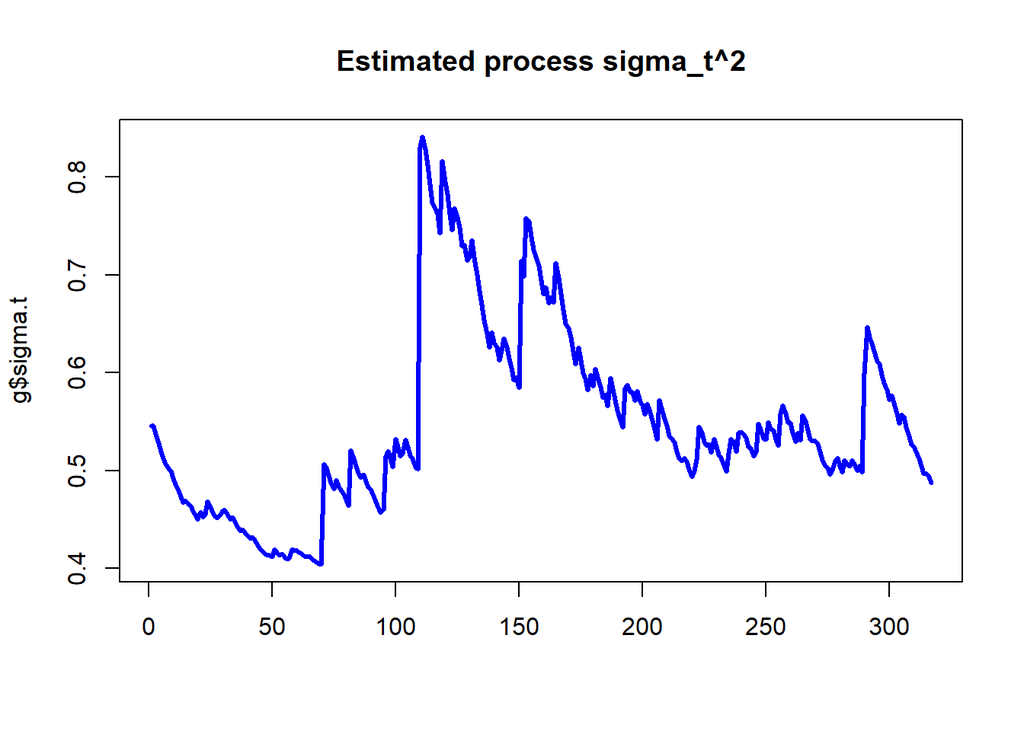

```r
matplot(g$sigma.t,lwd=3,col = "blue",type="l",main ="Estimated process sigma_t^2")
```

Остатки после оценки модели

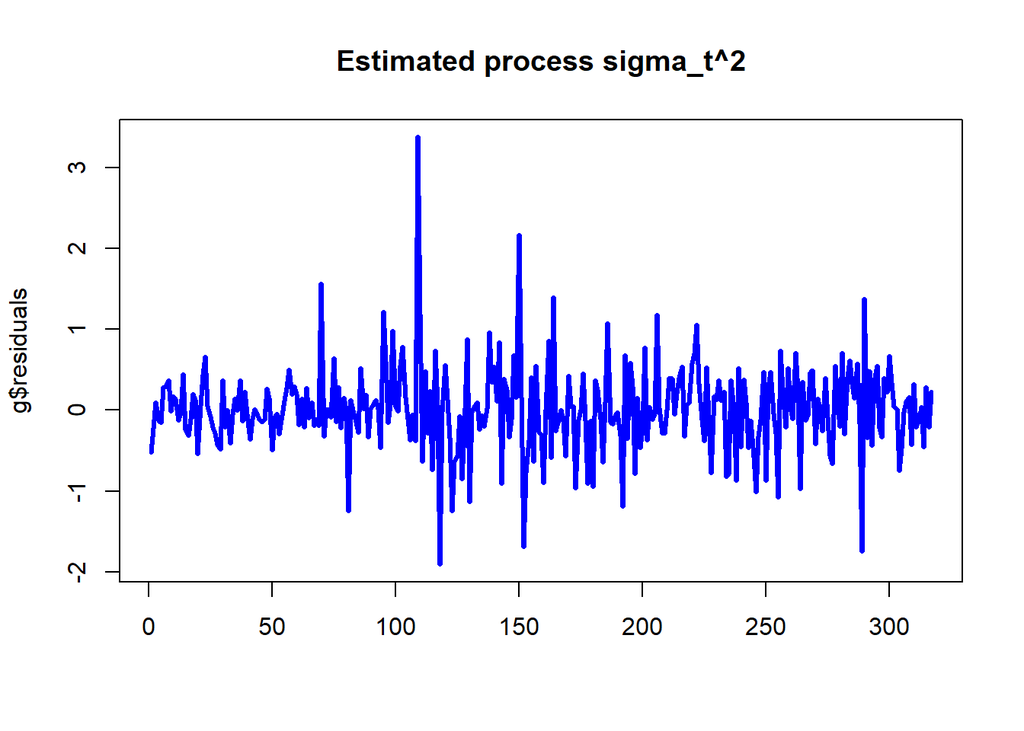

```r
matplot(g$residuals ,lwd=3,col = "blue",type="l",main ="Estimated process sigma_t^2")
```

QQ-график остатков

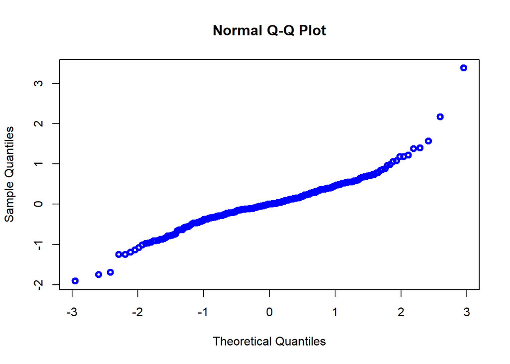

```r
qqnorm(g$residuals ,lwd=3,col = "blue")
```

## GARCH тест Engle

Естественный вопрос это имеет ли смысл оценивать гетероскедастическую модель или достаточно использовать только ARMA модель. Ответ на этот вопрос дает тест Engleа.

Тест Engle построен на основе того факта, что если остатки (определяемые как $\epsilon_t$ гетероскедастичны, то квадраты остатков ($\epsilon^2_t$) автокоррелированы.

Первый тип теста заключается в проверке того, являются ли квадраты остатков последовательностью белого шума, который называется Q-тестом Портманто и аналогичен тесту Льюнга-Бокса для квадратов остатков.

Второй тип теста, предложенный Энглом (1982), - это критерий множителя Лагранжа, который предназначен для подбора модели линейной регрессии для квадратов остатков и проверки значимости подобранной модели. Итак, нулевая гипотеза состоит в том, что возведенные в квадрат остатки представляют собой последовательность белого шума, а именно, остатки гомоскедастичны. Параметр запаздывания для вычисления статистики теста берется из целочисленной последовательности 1: min (24, n) с шагом 4, если n> 25, в противном случае 2, где n - количество неотмеченных наблюдений.

Сначала посмотрим как это работает действительно на белом шуме, а потом на доходностях рубля. Для этого воспользуемся пакетом `library(aTSA)` для теста на гетороскедастичность.

```r
  library(aTSA)
  set.seed(100)
  noise <- rnorm(200)
  mod_noise <- arima(noise,order = c(1,0,0))
  arch.test(mod_noise)
```

```
## ARCH heteroscedasticity test for residuals
## alternative: heteroscedastic
##
## Portmanteau-Q test:
##      order    PQ p.value
## [1,]     4  5.45   0.244
## [2,]     8  7.45   0.489
## [3,]    12 15.88   0.197
## [4,]    16 19.97   0.222
## [5,]    20 21.49   0.369
## [6,]    24 22.43   0.553
## Lagrange-Multiplier test:
##      order    LM  p.value
## [1,]     4 60.77 4.02e-13
## [2,]     8 24.67 8.69e-04
## [3,]    12 13.74 2.48e-01
## [4,]    16  8.47 9.04e-01
## [5,]    20  6.12 9.98e-01
## [6,]    24  4.53 1.00e+00
```

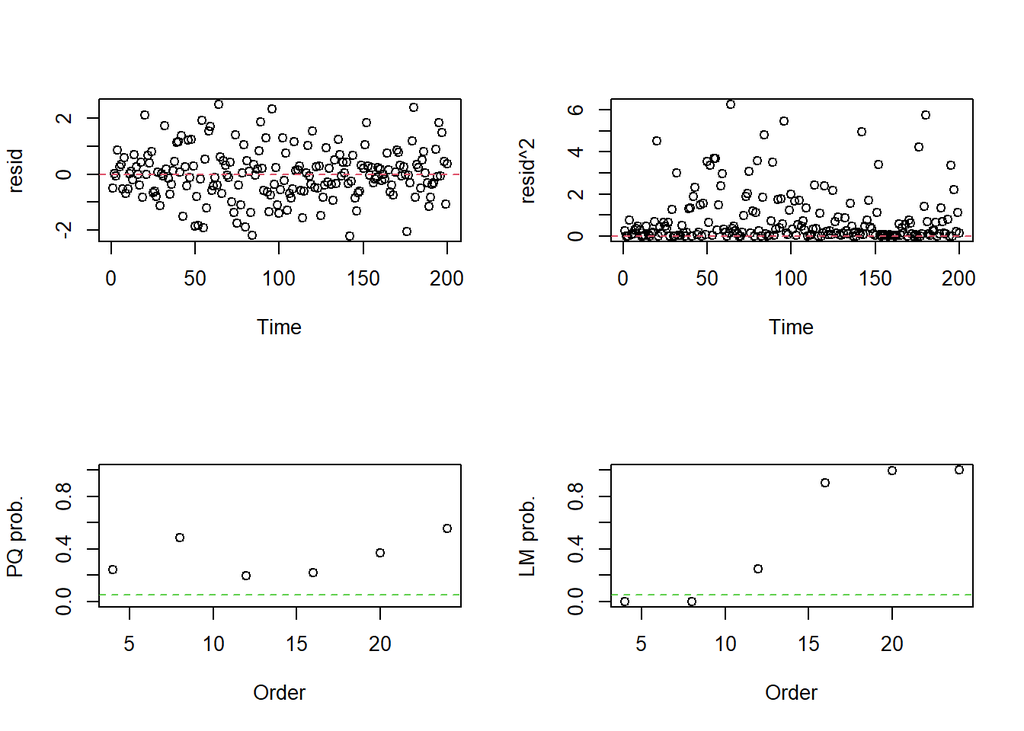

Первый тест не отвергает гипотезу о белом шуме на всех задержках. Второй тест не отвергает гипотезы о белом шуме на всех задержках, начиная с 12.

Теперь посмотрим для доходностей рубля

```r
mod <- arima(returns,order = c(1,0,0))
arch.test(mod)
```

```
## ARCH heteroscedasticity test for residuals
## alternative: heteroscedastic
##
## Portmanteau-Q test:
##      order    PQ p.value
## [1,]     4  1.89  0.7568
## [2,]     8  3.02  0.9331
## [3,]    12 15.60  0.2103
## [4,]    16 28.07  0.0310
## [5,]    20 30.29  0.0653
## [6,]    24 31.43  0.1419
## Lagrange-Multiplier test:
##      order    LM  p.value
## [1,]     4 488.2 0.00e+00
## [2,]     8 228.7 0.00e+00
## [3,]    12 109.6 0.00e+00
## [4,]    16  61.5 1.41e-07
## [5,]    20  46.1 4.74e-04
## [6,]    24  36.1 4.01e-02
```

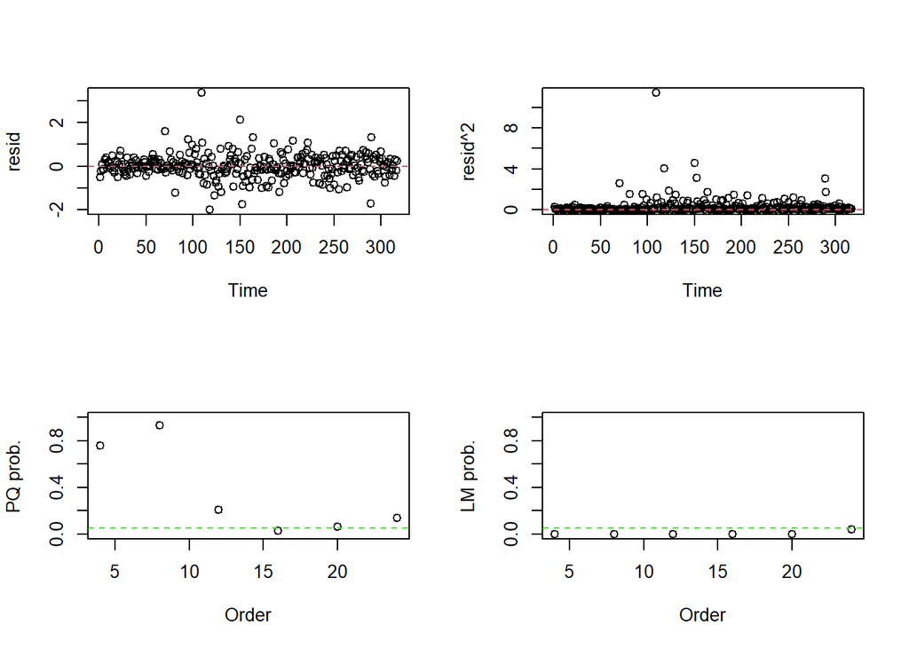

Если аналог теста Льюнга-Бокса говорит нам , что только на задержке 16 гипотеза о том, что это белый шум отвергается, то тест Engle отвергает гипотезу о белом шуме на всех задержках

## Экспоненциальная GARCH модель

Другой моделью, позволяющей учитывывать гетероскедастичность в прогнозах это экспоненциальная GARCH модель, предложена Nelson (1991). Пусть
$$u_{t}=\epsilon_{t}\sqrt{h_{t}}$$

где $\epsilon_{t}$ -независимые одинаково распределенные случайные величины с нулевым средним и единичной дисперсией. Nelson предложил следующую модель для логарифма $h_{t}$
$$ln h_{t}=\zeta+\sum_{j=1}^{\infty}\pi_{j}[|\epsilon_{t-j}|-E|\epsilon_{t-j}|+Λ\epsilon_{t-j}]$$
здесь все $\pi_{j}>0$. Параметр $Λ$ играет следующую роль. Если $Λ=0$ ,то вклад в общую волатильность проложительных значений $e_{t-j}>0$ будет таким же, как и отрицательных $e_{t-j}<0$. При $-1 < Λ<0$ вклад положительных увеличивает волатильность меньше, чем от отрицательных. При $Λ<-1$ приводит к тому, что положительные уменьшают волатильность, отрицательные увеличивают.
Естественной параметризацией данной модели является представление бесконечного полинома $\pi(B)$ как отношение двух полиномов конечного порядка
$$\pi(B)=((\alpha(L))/(1-\delta(L)))=((\alpha_{1}B+...+\alpha_{m}B^{m})/(1-\delta_{1}B-...-\delta_{r}B^{r})$$

аналогично тому, как это делалось в GARCH модели В этом случае исходную модель можно переписать следующим образом

$$ln h_{t}=k+\delta_{1}ln h_{t-1}+...+\delta_{r}ln h_{t-r}+
\alpha_{1}[|e_{t-1}|-E|e_{t-1}|+Λe_{t-1}]+
...+\alpha_{m}[|e_{t-m}|-E|e_{t-m}|+Λe_{t-m}]$$

где $κ=[1-\delta_1-...-\delta_{r}]\zeta$.

Параметры экспонециальной GARCH модели можно оценить методом максимального правдоподобия, естественно вид функции правдоподобия зависит от предположений относительно распределения шума $e_{t}$. Нельсон, в качестве распределения для $e_{t}$ предложил использовать обобщенное распределение ошибок, нормальзованное так, чтобы математическое ожидание было равно нулю, а дисперсия единице.
$$f(x)=((νe^{-(1/2)|(x/λ)|^{ν}})/(2^{((ν+1)/ν)}λΓ((1/ν))))$$

здесь $λ$- константа равная

$$λ={((2^{(-2/ν)}Γ((1/ν)))/(Γ((3/ν))))}^{(1/2)}$$

При $ν=2$ получим, что $λ=1$. В этом случае $f(x)$ - примет вид плотности стандартного нормального распределения. При $ν<2$ плотность $f(x)$ имеет более “толстый хвост” по сравнению со стандартным нормальным, а $ν>2$ наоборот, более “тонкий” Для стандартного нормального распределения (случай $ν=2$) математическое ожидание для модуля ошибки имеет вид

$$E|e_{t}|=√((2/π))$$

а при произвольном $ν>0$

$$E|e_{t}|=((λ2^{(1/ν)}Γ((2/ν)))/(Γ((1/ν))))$$

Плотность обощенного распределения ошибок при параметре $\nu=1,2,3$ выглядит следующим образом

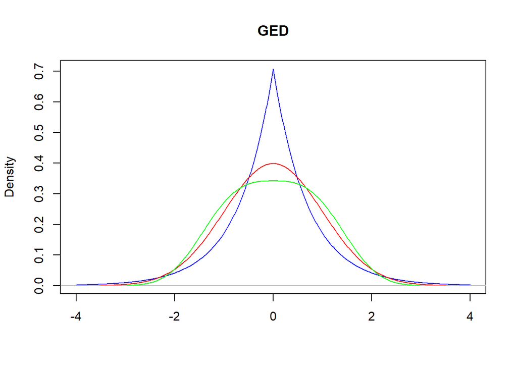

```r
x = seq(-4, 4, length = 501)
y = dged(x, mean = 0, sd = 1, nu = 1)

plot(x, y, type = "l", , col = "blue", main = "GED", ylab = "Density",
xlab = "")
y = dged(x, mean = 0, sd = 1, nu = 2)
lines(x, y, col = "red")
y = dged(x, mean = 0, sd = 1, nu = 3)
lines(x, y, col = "green")
abline(h = 0, col = "grey")
```

Для иллюстрации рассмотрим следующую модель Пусть моделью дневного дохода $r_{t}$ по некоторой акции является следующая модель
$$r_{t}=a+br_{t-1}+\delta h_{t}+u_{t}$$
где ошибка $u_{t}=e_{t}√(h_{t})$ и модель для $h_{t}$
$$ln h_{t}-\zeta_{t} = \delta_1(ln h_{t-1}-\zeta)+\delta_2(ln h_{t-2}-\zeta)+
α_1(|e_{t-1}|-E|e_{t-1}|+Λe_{t-1})+
α_2(|e_{t-2}|-E|e_{t-2}|+Λe_{t-2})$$

$\zeta$ и $ρ$- параметры, которые можно оценить методом максимального правдоподобия. Логарифм функции правдоподобия задается выражением
$$L=T{ln((ν/λ))-(1+(1/ν))ln2-ln(Γ((1/ν)))}-
(1/2)∑_{t=1}^{T}|(((r_{t}-a-br_{t-1}-\delta h_{t}))/(λ√(h_{t})))|^{ν}-(1/2)∑_{t=1}^{T}ln h_{t}$$

Где последовательность $h_{t}, t=1,...,T$ получают итерационно

```r
library(rugarch)
source('./garchM.R')
data <- read.csv('./RubleRates.csv',sep=',')
head(data)
```

```
##          X318x6      Rub.Usd        brent        sp500      GAZPROM
## 1 1/11/16 12:00 -0.005162439  0.009705793  0.006734183  0.001774754
## 2 1/11/16 13:00 -0.002184241  0.005407029 -0.003577910 -0.002952683
## 3 1/11/16 14:00  0.001061344 -0.008066926 -0.002706078 -0.004145998
## 4 1/11/16 15:00 -0.001162265  0.001807229  0.002400334 -0.002155974
## 5 1/11/16 16:00 -0.001411732 -0.000300661 -0.001561687  0.001043064
## 6 1/11/16 17:00  0.003057320  0.001203008  0.003076121  0.000893123
##           Gold       EUR.USD
## 1 -0.005335021 -0.0015779090
## 2 -0.000727273  0.0001286370
## 3  0.004002911  0.0014607660
## 4 -0.000906125 -0.0001743020
## 5  0.000544168 -0.0000367016
## 6 -0.002356780 -0.0015874040
```

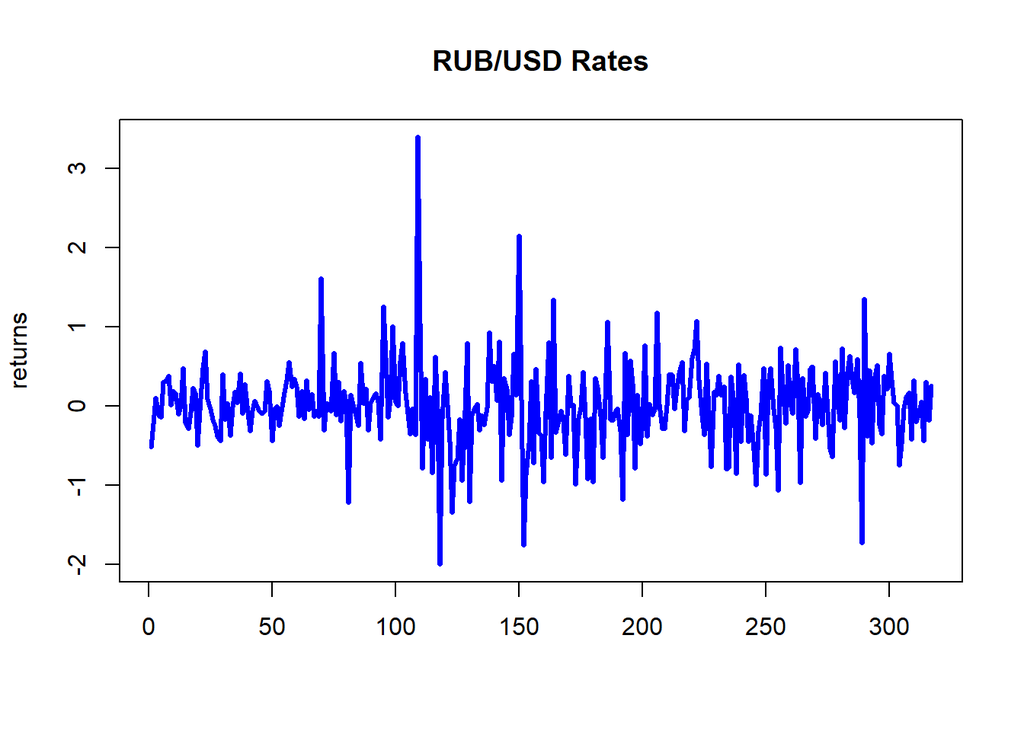

```r
rubusd <- data$Rub.Usd
returns <- rubusd * 100
matplot(returns,type="l",lwd=3,col = "blue",main = "RUB/USD Rates")
```

Гистограмма рейтов по сравнению с плотностью нормального распределения

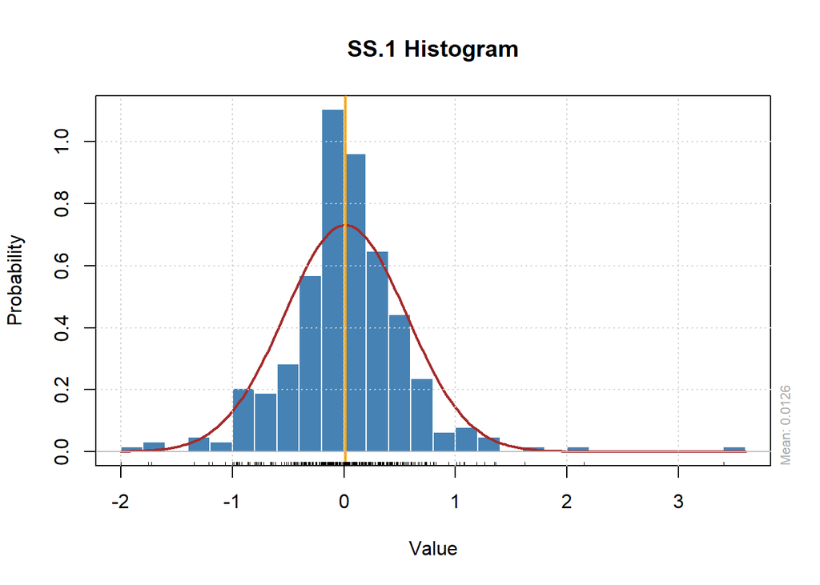

```r
  histPlot(as.timeSeries(returns))
```

```r
spec <- ugarchspec(mean.model = list(armaOrder = c(1, 0)),variance.model = list(model ="eGARCH",garchOrder = c(1,1)),distribution.model = "norm")
fit <- ugarchfit(returns, spec = spec)
fit
```

```
##
## *---------------------------------*
## *          GARCH Model Fit        *
## *---------------------------------*
##
## Conditional Variance Dynamics
## -----------------------------------
## GARCH Model  : eGARCH(1,1)
## Mean Model   : ARFIMA(1,0,0)
## Distribution : norm
##
## Optimal Parameters
## ------------------------------------
##         Estimate  Std. Error   t value Pr(>|t|)
## mu      0.052200    0.020116    2.5950 0.009460
## ar1    -0.092696    0.054388   -1.7043 0.088317
## omega   0.009938    0.005633    1.7642 0.077690
## alpha1  0.114234    0.021211    5.3855 0.000000
## beta1   1.000000    0.000145 6879.6062 0.000000
## gamma1  0.042805    0.010375    4.1258 0.000037
##
## Robust Standard Errors:
##         Estimate  Std. Error   t value Pr(>|t|)
## mu      0.052200    0.024682    2.1149 0.034441
## ar1    -0.092696    0.045566   -2.0343 0.041922
## omega   0.009938    0.006940    1.4320 0.152148
## alpha1  0.114234    0.031557    3.6199 0.000295
## beta1   1.000000    0.000386 2590.2789 0.000000
## gamma1  0.042805    0.013375    3.2005 0.001372
##
## LogLikelihood : -243.1919
##
## Information Criteria
## ------------------------------------
##
## Akaike       1.5722
## Bayes        1.6433
## Shibata      1.5715
## Hannan-Quinn 1.6006
##
```

[output cut: 43 more lines]

```
## Negative Sign Bias  0.0929 0.9260
## Positive Sign Bias  0.1229 0.9022
## Joint Effect        3.3602 0.3393
##
##
## Adjusted Pearson Goodness-of-Fit Test:
## ------------------------------------
##   group statistic p-value(g-1)
## 1    20     40.67     0.002673
## 2    30     50.67     0.007649
## 3    40     61.68     0.011802
## 4    50     79.69     0.003643
##
##
## Elapsed time : 0.3977919
```

Повторим оценку, но теперь будем использовать обобщенное распределение ошибок для $\epsilon_t$

```r
spec1 <- ugarchspec(mean.model = list(armaOrder = c(1,0)),
        variance.model = list(model ="eGARCH",
        garchOrder = c(1,1)),
        distribution.model = "ged")
fit1 <- ugarchfit(returns, spec = spec1)
fit1
```

```
##
## *---------------------------------*
## *          GARCH Model Fit        *
## *---------------------------------*
##
## Conditional Variance Dynamics
## -----------------------------------
## GARCH Model  : eGARCH(1,1)
## Mean Model   : ARFIMA(1,0,0)
## Distribution : ged
##
## Optimal Parameters
## ------------------------------------
##         Estimate  Std. Error  t value Pr(>|t|)
## mu      0.008342    0.002695  3.09565 0.001964
## ar1    -0.000492    0.001529 -0.32167 0.747699
## omega  -0.002287    0.016299 -0.14030 0.888424
## alpha1  0.080586    0.018950  4.25268 0.000021
## beta1   1.000000    0.013846 72.22553 0.000000
## gamma1  0.083736    0.013473  6.21527 0.000000
## shape   1.017840    0.101937  9.98503 0.000000
##
## Robust Standard Errors:
##         Estimate  Std. Error  t value Pr(>|t|)
## mu      0.008342    0.000361 23.10867 0.000000
## ar1    -0.000492    0.000059 -8.35116 0.000000
## omega  -0.002287    0.010916 -0.20947 0.834078
## alpha1  0.080586    0.020547  3.92195 0.000088
## beta1   1.000000    0.010099 99.01480 0.000000
## gamma1  0.083736    0.035989  2.32670 0.019981
## shape   1.017840    0.114701  8.87389 0.000000
##
## LogLikelihood : -221.8654
##
## Information Criteria
## ------------------------------------
##
## Akaike       1.4439
## Bayes        1.5269
## Shibata      1.4430
```

[output cut: 46 more lines]

```
## Negative Sign Bias  0.1201 0.9045
## Positive Sign Bias  0.4866 0.6269
## Joint Effect        2.6544 0.4480
##
##
## Adjusted Pearson Goodness-of-Fit Test:
## ------------------------------------
##   group statistic p-value(g-1)
## 1    20     22.87       0.2429
## 2    30     23.03       0.7751
## 3    40     35.93       0.6105
## 4    50     37.10       0.8938
##
##
## Elapsed time : 1.046519
```

По критерию Акаике вторая модель предпочтительней первой модели(значение критерия меньше), хотя во второй модели больше параметров (добавился параметр shape $\mu$). Логарифм функции правдоподобия больше, что также в пользу второй модели.